# practical machine project

Huda

9/20/2020

# Introduction

Using devices such as Jawbone Up, Nike FuelBand, and Fitbit it is now possible to collect a large amount of data about personal activity relatively inexpensively. These type of devices are part of the quantified self movement - a group of enthusiasts who take measurements about themselves regularly to improve their health, to find patterns in their behavior, or because they are tech geeks. One thing that people regularly do is quantify how much of a particular activity they do, but they rarely quantify how well they do it. In this project, our goal will be to use data from accelerometers on the belt, forearm, arm, and dumbell of 6 participants. They were asked to perform barbell lifts correctly and incorrectly in 5 different ways. More information is available from the website here: http://web.archive.org/web/20161224072740/http:/groupware.les.inf.puc-rio.br/har

## Data Descriptions

The training data for this project are available here:

https://d396qusza40orc.cloudfront.net/predmachlearn/pml-training.csv

The test data are available here:

https://d396qusza40orc.cloudfront.net/predmachlearn/pml-testing.csv

The data for this project come from this source: http://web.archive.org/web/20161224072740/http:/groupware.les.inf.puc-rio.br/har.

```r
###Load Libraries required
library(knitr)

library(caret)
```

```r
library(rpart)
library(rpart.plot)
library(rattle)
library(randomForest)
library(RColorBrewer)
library(RGtk2)
library(gbm)
```

## Loading Data

```r
train_url<- "https://d396qusza40orc.cloudfront.net/predmachlearn/pml-training.csv"
test_url<- "https://d396qusza40orc.cloudfront.net/predmachlearn/pml-testing.csv"
training_data<- read.csv(url(train_url))
testing_data<- read.csv(url(test_url))
dim(training_data)
```

```
## [1] 19622   160
```

```r
dim(testing_data)
```

```
## [1]  20 160
```

## Data Cleansing

```r
###Removing Variables which are having Nearly Zero Variance.
nzv <- nearZeroVar(training_data)

train_data <- training_data[,-nzv]
test_data <- testing_data[,-nzv]

dim(train_data)
```

```
## [1] 19622   100
```

```r
###Removing NA Values of Variables.
na_val_col <- sapply(train_data, function(x) mean(is.na(x))) > 0.95
train_data <- train_data[,na_val_col == FALSE]
test_data <- test_data[,na_val_col == FALSE]

dim(train_data)
```

```
## [1] 19622    59
```

```r
###Removing the first 7 Variables which are Non-Numeric.
train_data<- train_data[, 8:59]
test_data<- test_data[, 8:59]
dim(train_data)
```

```
## [1] 19622    52
```

## Data Partioning

In this we will seggregate our train_data in two parts “training”(60% of data) and “testing”(40% of data)/ Validateion set.

```r
inTrain<- createDataPartition(train_data$classe, p=0.6, list=FALSE)
inTrain<- createDataPartition(train_data$classe, p=0.6, list=FALSE)
training<- train_data[inTrain,]
testing<- train_data[-inTrain,]
dim(training)
```

```
## [1] 11776    52
```

### Decision Tree Model and Prediction

[figure not shown]

```r
###Fit the model and plot
library(rattle)
DT_model<- train(classe ~. , data=training, method= "rpart")
fancyRpartPlot(DT_model$finalModel)
```

```r
###Prediction
set.seed(21243)
DT_prediction<- predict(DT_model, testing)
confusionMatrix(DT_prediction, testing$classe)
```

```
## Confusion Matrix and Statistics
##
##           Reference
## Prediction    A    B    C    D    E
##          A 2027  665  639  575  351
##          B   32  487   46  236  286
##          C  133  314  552  175  345
##          D   39   51  131  300   62
##          E    1    1    0    0  398
##
## Overall Statistics
##
##                Accuracy : 0.4797
##                  95% CI : (0.4686, 0.4909)
##     No Information Rate : 0.2845
##     P-Value [Acc > NIR] : < 2.2e-16
##
##                   Kappa : 0.3186
##
##  Mcnemar's Test P-Value : < 2.2e-16
##
## Statistics by Class:
##
##                      Class: A Class: B Class: C Class: D Class: E
## Sensitivity            0.9082  0.32082  0.40351  0.23328  0.27601
## Specificity            0.6028  0.90518  0.85073  0.95686  0.99969
## Pos Pred Value         0.4762  0.44802  0.36340  0.51458  0.99500
## Neg Pred Value         0.9429  0.84746  0.87103  0.86424  0.85979
## Prevalence             0.2845  0.19347  0.17436  0.16391  0.18379
## Detection Rate         0.2583  0.06207  0.07035  0.03824  0.05073
## Detection Prevalence   0.5426  0.13854  0.19360  0.07431  0.05098
## Balanced Accuracy      0.7555  0.61300  0.62712  0.59507  0.63785
```

```r
set.seed(26817)
###Fit the model
RF_model<- train(classe ~. , data=training, method= "rf", ntree=100)
###Prediction
RF_prediction<- predict(RF_model, testing)
RF_cm<-confusionMatrix(RF_prediction, testing$classe)
RF_cm
```

```
## Confusion Matrix and Statistics
##
##           Reference
## Prediction    A    B    C    D    E
##          A 2230   23    0    0    0
##          B    2 1489   17    0    0
##          C    0    5 1345    7    4
##          D    0    0    6 1279    4
##          E    0    1    0    0 1434
##
## Overall Statistics
##
##                Accuracy : 0.9912
##                  95% CI : (0.9889, 0.9932)
##     No Information Rate : 0.2845
##     P-Value [Acc > NIR] : < 2.2e-16
##
##                   Kappa : 0.9889
##
##  Mcnemar's Test P-Value : NA
##
## Statistics by Class:
##
##                      Class: A Class: B Class: C Class: D Class: E
## Sensitivity            0.9991   0.9809   0.9832   0.9946   0.9945
## Specificity            0.9959   0.9970   0.9975   0.9985   0.9998
## Pos Pred Value         0.9898   0.9874   0.9882   0.9922   0.9993
## Neg Pred Value         0.9996   0.9954   0.9965   0.9989   0.9988
## Prevalence             0.2845   0.1935   0.1744   0.1639   0.1838
## Detection Rate         0.2842   0.1898   0.1714   0.1630   0.1828
## Detection Prevalence   0.2872   0.1922   0.1735   0.1643   0.1829
## Balanced Accuracy      0.9975   0.9889   0.9904   0.9965   0.9971
```

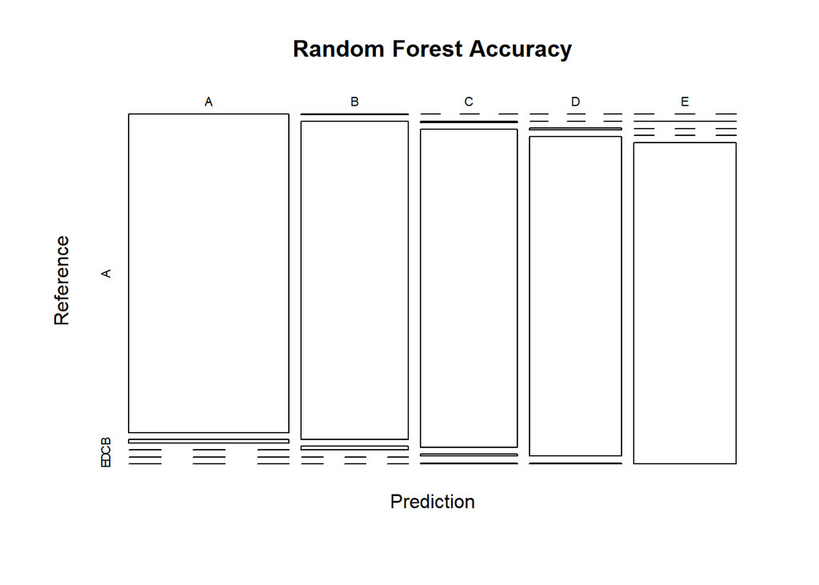

```r
###plot
plot(RF_cm$table, col=RF_cm$byClass, main="Random Forest Accuracy")
```

From the Random Forest Model we see the prediction accuracy is 99% which is close to perfect accuracy level.

### Gradient Boosting Model and Prediction

```r
set.seed(25621)
gbm_model<- train(classe~., data=training, method="gbm", verbose= FALSE)
gbm_model$finalmodel
```

```r
###Prediction

gbm_prediction<- predict(gbm_model, testing)
gbm_cm<-confusionMatrix(gbm_prediction, testing$classe)
gbm_cm
```

```
## Confusion Matrix and Statistics
##
##           Reference
## Prediction    A    B    C    D    E
##          A 2196   71    0    0    2
##          B   23 1399   45    7   17
##          C    6   43 1299   33   17
##          D    6    2   20 1233   15
##          E    1    3    4   13 1391
##
## Overall Statistics
##
##                Accuracy : 0.9582
##                  95% CI : (0.9535, 0.9625)
##     No Information Rate : 0.2845
##     P-Value [Acc > NIR] : < 2.2e-16
##
##                   Kappa : 0.9471
##
##  Mcnemar's Test P-Value : 2.506e-09
##
## Statistics by Class:
##
##                      Class: A Class: B Class: C Class: D Class: E
## Sensitivity            0.9839   0.9216   0.9496   0.9588   0.9646
## Specificity            0.9870   0.9855   0.9847   0.9934   0.9967
## Pos Pred Value         0.9678   0.9383   0.9292   0.9663   0.9851
## Neg Pred Value         0.9935   0.9813   0.9893   0.9919   0.9921
## Prevalence             0.2845   0.1935   0.1744   0.1639   0.1838
## Detection Rate         0.2799   0.1783   0.1656   0.1572   0.1773
## Detection Prevalence   0.2892   0.1900   0.1782   0.1626   0.1800
## Balanced Accuracy      0.9854   0.9535   0.9671   0.9761   0.9807
```

From the Gradient Boosting Model we see the prediction accuracy is 96% which is satisfied.

```r
##we have taken Random Forest and Gradient Boosting Model because it reach to satisfied prediction level. we are compairing the both model which is more accurate.
RF_cm$overall
```

```
##       Accuracy          Kappa  AccuracyLower  AccuracyUpper   AccuracyNull
##      0.9912057      0.9888728      0.9888833      0.9931513      0.2844762
## AccuracyPValue  McnemarPValue
##      0.0000000            NaN
```

```r
gbm_cm$overall
```

```
##       Accuracy          Kappa  AccuracyLower  AccuracyUpper   AccuracyNull
##   9.581953e-01   9.470938e-01   9.535296e-01   9.625166e-01   2.844762e-01
## AccuracyPValue  McnemarPValue
##   0.000000e+00   2.505627e-09
```

## Conclusion

we conclude that, Random Forest is more accurate than Gradient Boosting Model at upto 99% of accuracy level.

## Prediction - using Random Forest MOdel on testing data.

```r
prediction_test<- predict(RF_model, test_data)
prediction_test
```

```
##  [1] B A B A A E D B A A B C B A E E A B B B
## Levels: A B C D E
```